# Diversity in a Globalized World

Lecture 4: Who Lives Next to Whom

Bogdan G. Popescu

bgpopescu@tec.mx

Tecnológico de Monterrey

## Where the week has been

- **Monday:** a shock landed on particular **places**, not on a country
- **Tuesday:** those same places voted differently afterwards
- **Wednesday:** some people left — and the money came back
- **Today:** who lives next to whom — and why

Knowing who lives in a country is not the same as knowing who lives next to whom.

## Four numbers

- **23.2 million** *identify* as indigenous — **19.4%** of everyone aged 3 or over
- **7.4 million** *speak* an indigenous language — **5.8%** of the population
- **2.6 million** identify as Afro-Mexican — **2%**
- **371** municipios are majority indigenous-speaking; **1,047** are under 1%

**The first two are not the same question.** Of the 23.2 million who identify as indigenous, **seven in ten do not speak an indigenous language.**

The country is diverse. Most of the places in it are not.

## Those three numbers, on a map

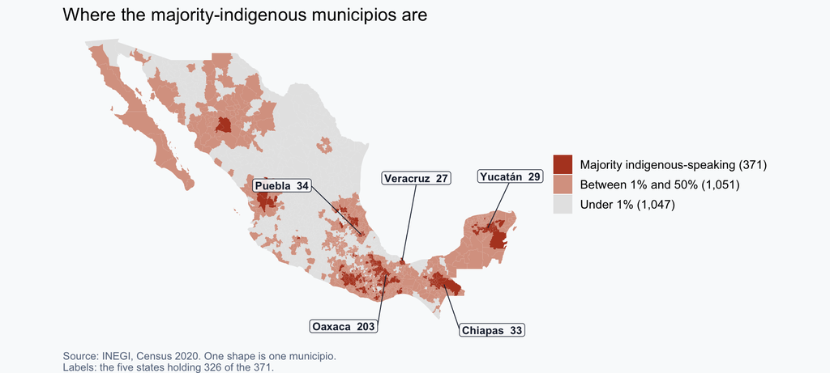

Figure 1

The dark municipios are the **371**. **Oaxaca alone holds 203 of them.**

## Learning objectives

- Say **where** difference sits in Mexico, and separate three questions people run together:
  - **how much**
  - **which places**
  - **how mixed**
- Turn “this city is divided” into **a number** — and say what that number leaves out
- Explain how a city can divide itself with **nobody intending it**, and why the sorting outlives whatever started it
- Say whether living closer together **actually reduces prejudice**, and under what conditions

# I. How Different Is Mexico?

## Diversity is not spread evenly

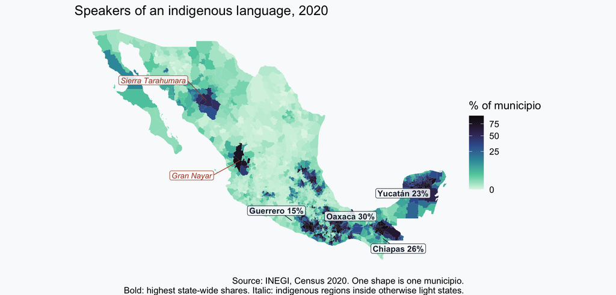

Figure 2

## A second map, a different geography

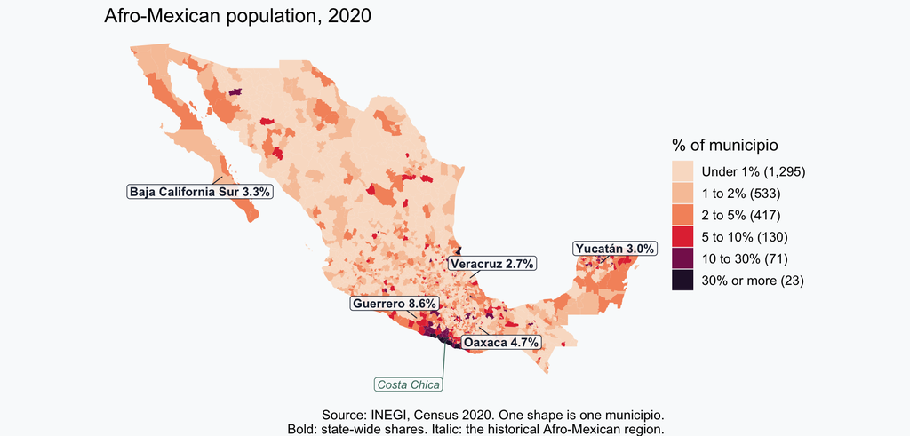

Figure 3

Source: INEGI, *Perfil sociodemográfico de la población afrodescendiente en México* (Censo 2020).

## Same population, different segregation

Both cities have **100 residents: 25 blue and 75 green.**

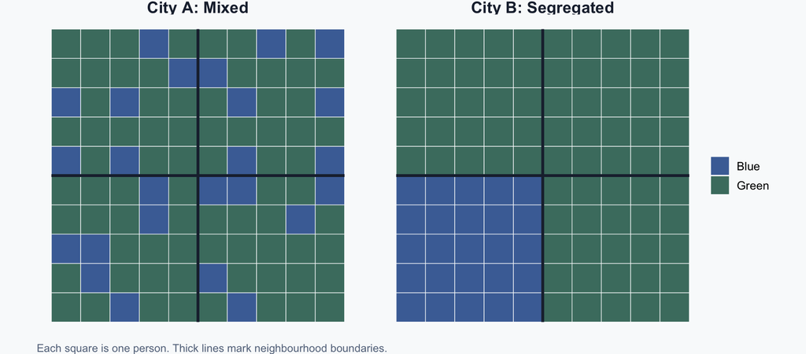

Figure 4

**Same composition. Different segregation.**

## What do our Mexico maps actually tell us?

|  | The question | What we learn |
| --- | --- | --- |
| **Composition** | Who lives in each place? | A municipio is **30%** indigenous-speaking |
| **Geographic distribution** | Where are groups located? | Which municipios have the **highest shares** of indigenous-language speakers |
| **Segregation** | Do groups live in the same neighbourhoods? | **Our maps cannot tell us** |

Our maps show **who lives where across municipios**.

They do not show whether indigenous-language speakers and non-speakers live **together or apart within a municipio**.

To answer that question, we need **smaller geographical units**.

## So what?

- Mexico is diverse **as a country**
- **83%** of Mexicans live in a municipio that is under **5%** indigenous-speaking
- “How much difference?” and “who meets it?” are different questions

Which raises the question of whether where you live also shapes how you live.

# II. Difference and Disadvantage

## The two maps look alike

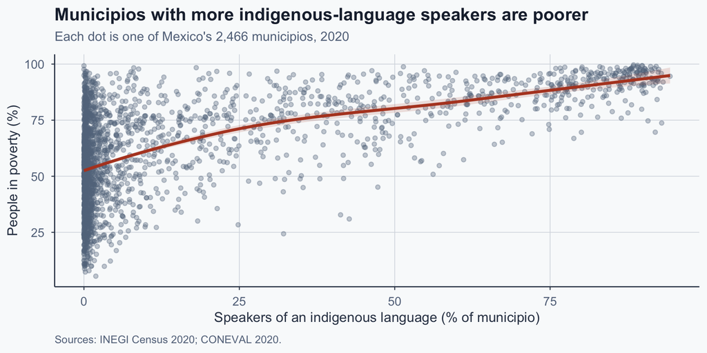

Figure 5

## What this does and does not say

- The pattern is strong and it is real
- It does **not** tell us why
- Remote municipios are poorer, and also more indigenous

Geography, history and discrimination all predict the same map. A correlation cannot separate them — which is why the rest of the lecture takes the mechanisms one at a time.

## A municipio is not a person

Does this graph prove that indigenous-language speakers are **poorer than non-speakers living in the same municipio**?

### No.

Imagine a municipio where: - **80%** speak an indigenous language - **60%** live in poverty

The poverty rate could be **60% for both groups**.

Our graph tells us **which municipios are poor**, not **which people within them are poor**.

This is the **ecological fallacy**: assuming that a relationship between places also holds between individuals.

## Poorer municipios, poorer people?

*Hypothetical example: two municipios, 100 residents each.*

**Who lives where?**

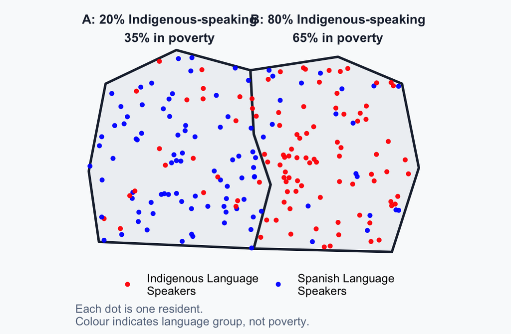

Figure 6

**Who is poor within each municipio?**

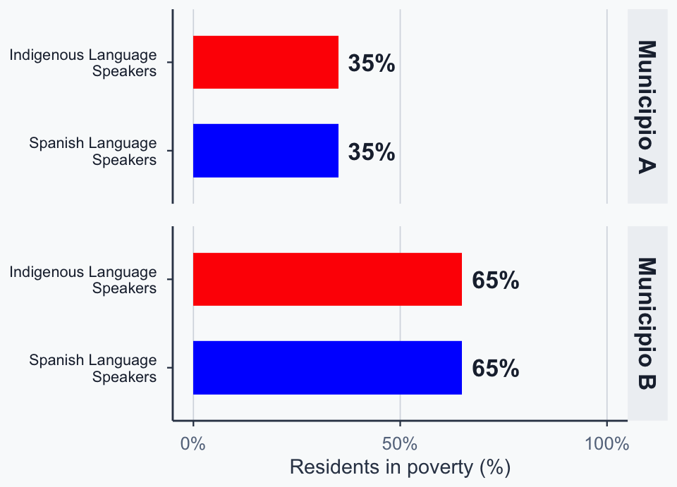

Figure 7

## Who is actually poor?

*Hypothetical example: 100 residents in each municipio.*

|  | Municipio A | Municipio B |
| --- | --- | --- |
| Indigenous-language speakers | 20 | 80 |
| Spanish-only speakers | 80 | 20 |
| Indigenous-language speakers in poverty | 7 (35%) | 52 (65%) |
| Spanish-only speakers in poverty | 28 (35%) | 13 (65%) |
| **Total in poverty** | **35 (35%)** | **65 (65%)** |

## Who is actually poor?

**Between municipios:** More indigenous-language speakers, more poverty.

**Within each municipio:** Both groups have the **same poverty rate**.

**Ecological fallacy:** Assuming that a relationship between places also holds between individuals within those places.

## So what?

- Where a group lives is bound up with how it lives
- At this scale we compare **whole municipios**
- The interesting sorting happens at a much smaller scale

So let us take one city apart.

# III. Sorting Inside One City

## Monterrey, thirteen municipios

Same question, different cleavage: this metro is only **0.4% to 4%** indigenous-speaking, so the difference you can *see* inside it is **class**.

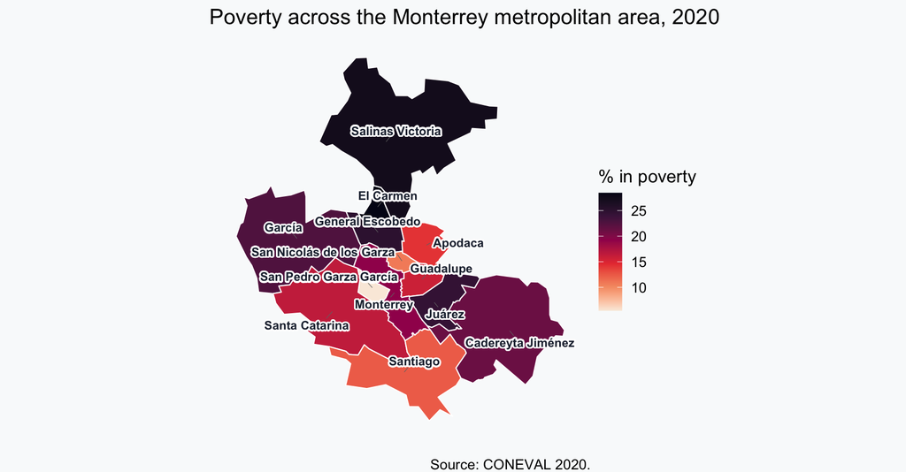

Figure 8

## The same city, ranked

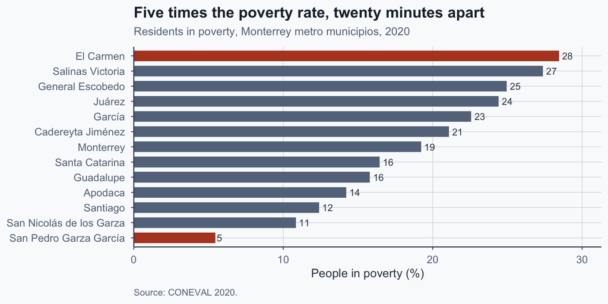

Figure 9

## Putting a number on unevenness

**The index of dissimilarity** asks one question: *what share of one group would have to move for the two groups to be spread evenly across the city?*

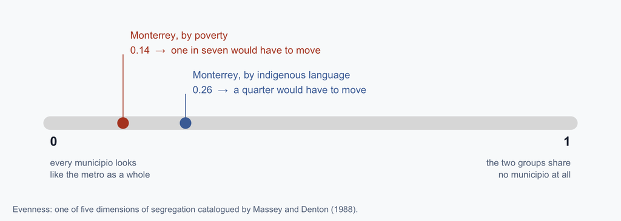

Figure 10

Both sit near the left end. A five-fold gap between two municipios is not yet a divided city.

## Which city is more segregated?

Two cities, four neighbourhoods. **Same 200 blue and 200 green in each.**

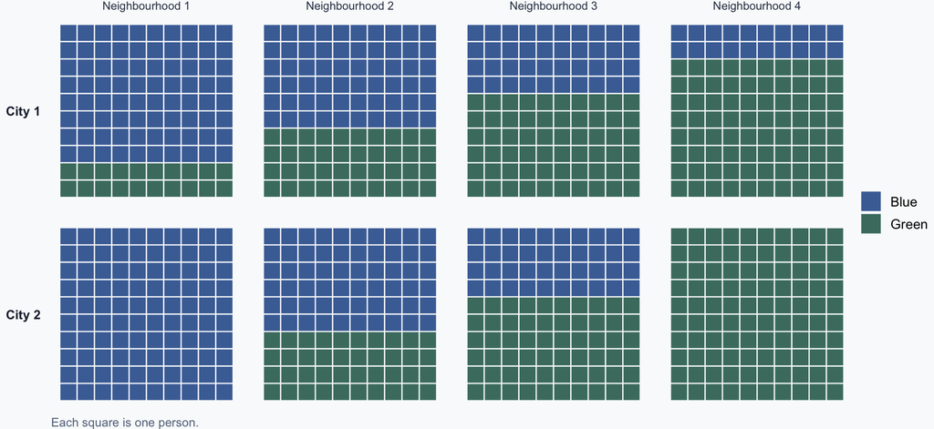

Figure 11

## Why City 2?

- The **middle two** neighbourhoods are identical in both cities
- The cities differ only at the **ends** — and City 2 pushed those all the way
- One neighbourhood is all blue, the other all green

$$D \;=\; \tfrac{1}{2}\sum_{i}\left|\;\frac{b_i}{B}-\frac{g_i}{G}\;\right|$$

**City 1** · ½(0.3 + 0.1 + 0.1 + 0.3) = **0.40** — 40% of blue would have to move

**City 2** · ½(0.5 + 0.1 + 0.1 + 0.5) = **0.60** — 60% would

## Is Monterrey unusual?

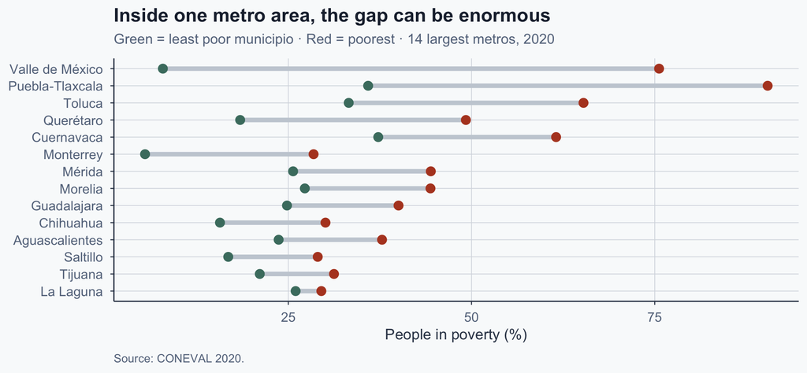

Figure 12

But read it carefully: this is a gap **between** municipios. It says the groups are sorted. It does not say how **mixed** any one of them is — that is the third word.

## One honest caveat

In the Valle de México the gap runs from **8%** to **76%**. Monterrey’s runs from **5%** to **28%**. Tijuana’s is only **10** points wide.

But these compare **municipios**, and Monterrey municipio alone holds over a million people.

Real segregation happens street by street. Every number here is a **floor**, not a ceiling. Say so when you report one.

You have met this problem all week: Monday’s commuting zones, Wednesday’s whole-city comparison for Mariel. Each time, the unit decided what you could see.

## Exercise 1 — Where would you look?

You want to know whether your own city is segregated.

**What is the smallest unit you could get data for, and why does that choice change your answer?**

Then: name one thing your measure would still miss entirely.

Five minutes, in pairs.

## Exercise 1 — Responses

- Mexico publishes four levels: **estado → municipio → AGEB → manzana**, the city block
- The smaller the unit, the **more** segregation you find — big units average it away
- A municipio of a million people can look mixed while every street in it is not

**What your measure still misses:** where people spend the *day*. Living apart and meeting are different things — people work, study and shop across the line.

## Same city, two answers

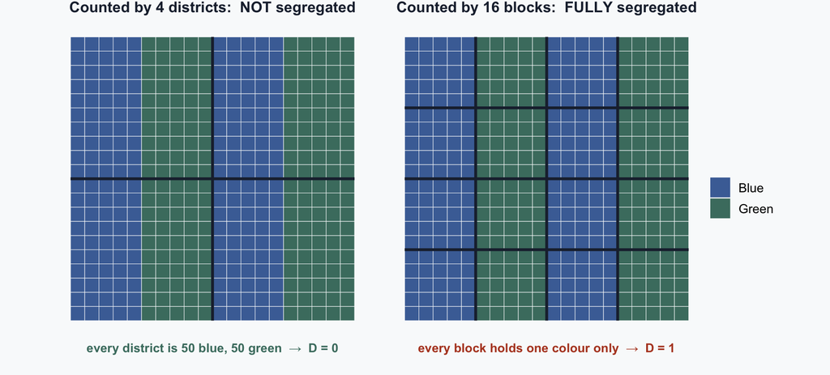

Figure 13

**Same 400 people. Same city.** Drawn one way it is perfectly mixed; drawn another way it is completely divided. Nothing moved.

## So what?

- Sorting is measurable, and the measure depends on the unit
- Prosperous-looking cities contain enormous internal gaps
- Nothing so far tells us **why** the sorting happens

The obvious answer is that people are prejudiced. The obvious answer turns out to be unnecessary.

# IV. Why Sorting Persists

## Schelling’s question

In 1971 Thomas Schelling asked what would happen if people were only **mildly** concerned about their neighbours.

Not hostile. Not seeking to exclude anyone. Simply preferring not to be an extreme minority on their own street.

**Your** intuition says mild preferences should produce mild sorting. Hold on to that, and watch what the model does.

## What actually happens

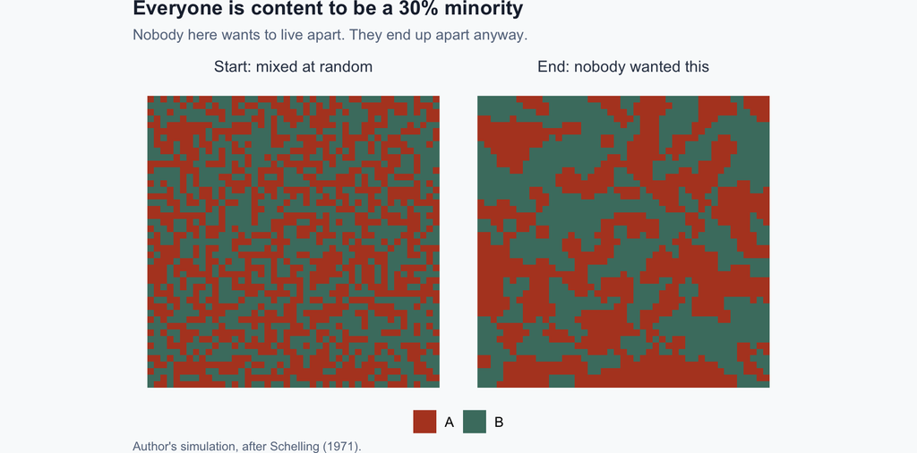

Figure 14

## Two lessons, pulling opposite ways

At the start, the average person’s neighbours were **50%** their own group. At the end: **75%**.

- **You do not need bigots.** Nobody here is hostile, no law excludes anyone, and nobody coordinated
- So finding segregation does not prove that anyone is prejudiced
- But it also does not prove that nobody is

## The mechanism

```
%%{init: {"flowchart": {"useMaxWidth": true, "htmlLabels": true, "padding": 26,
                        "nodeSpacing": 30, "rankSpacing": 70,
                        "width": 1150, "height": 650},
          "themeVariables": {"fontSize": "22px", "fontFamily": "Arial, Helvetica, sans-serif"}} }%%
flowchart LR
  A["A mild<br/>preference"] --> B["A few<br/>people move"]
  B --> C["The street<br/>tips"]
  C --> D["Neighbours<br/>move too"]
  D -->|"and again"| B
  C --> E["Segregation"]
```

Figure 15

Author’s illustration, after Schelling (1971). The loop is the whole point.

## Watch the street tip

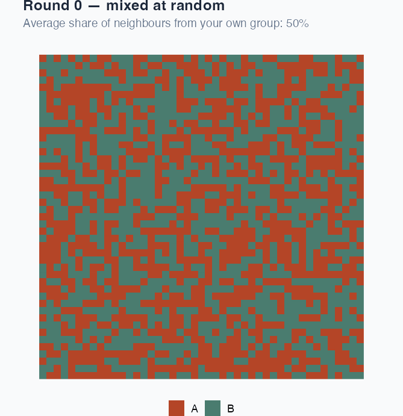

Author’s simulation, after Schelling (1971). Each round, people with fewer than 30% same-colour neighbours swap houses with each other. Nobody’s preference changes.

## But is anyone discriminating?

Schelling shows sharp sorting does not **require** hostility or exclusion. That is not evidence that there is none of either. So stop inferring it from maps and test it directly:

- Send two applications for the same thing — a job, a flat
- Make them **identical** except one detail: a name, a photo
- Count who replies

Because everything else is held fixed, a gap in replies is hard to explain away. This is the **correspondence study** design.

## What those tests find

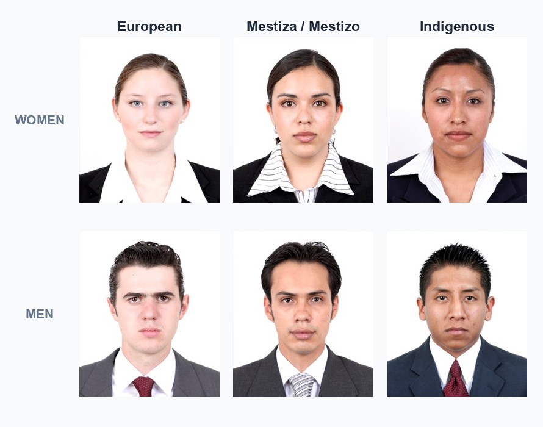

Same clothes. Same pose. **Identical CV behind each one.**

- Arceo-Gómez and Campos-Vázquez sent these across Mexico
- Indigenous-looking **women** were called back less
- **Men** showed no penalty

Photographs: Arceo-Gómez & Campos-Vázquez, Appendix A. Bertrand and Mullainathan (2004) found a comparable gap in the United States using names alone.

## Mind the domain

- This is a **hiring** experiment.
- It shows discrimination is live in Mexico — it does **not** show that discrimination produced the sorting you just saw
- Those are two claims, and only one of them has been tested here

The design travels, though: run it on **landlords** instead of employers and you have a test of the housing market. That has been done in Sweden and the United States — rarely in Mexico.

## Does living closer help reduce discrimination?

Two intuitions, pointing opposite ways:

- **Contact breeds friction** — difference itself is a source of conflict
- **Contact breeds familiarity** — people who meet stop generalising

## Allport’s conditions

```
%%{init: {"flowchart": {"useMaxWidth": true, "htmlLabels": true, "padding": 22,
                        "nodeSpacing": 12, "rankSpacing": 110,
                        "width": 1150, "height": 620},
          "themeVariables": {"fontSize": "22px", "fontFamily": "Arial, Helvetica, sans-serif"}} }%%
flowchart LR
  A["Equal<br/>standing"] --> X["Intergroup<br/>contact"]
  B["A shared<br/>goal"] --> X
  C["Working<br/>together"] --> X
  D["Institutional<br/>support"] --> X
  X --> E["Less<br/>prejudice"]
```

Figure 16

Author’s illustration, after Allport (1954). Contact is the mechanism; the four are the conditions Allport said it needs to work. Note what is *not* here — proximity on its own.

## The evidence, fifty years later

Pettigrew and Tropp (2006) pooled **515 studies**. Contact reduces prejudice on average — and Allport’s conditions **strengthen** that effect rather than being required for it.

- Contact usually helps, conditions or no conditions
- Contact under Allport’s conditions helps considerably more
- Contact between unequals, competing, can make things worse

## So what?

- Contact needs **opportunities** for contact
- Segregation does not abolish them — people still work, study, commute and shop across the line, as you said in Exercise 1
- What it thins out is the **sustained, equal-footing, repeated** kind — exactly the kind the evidence rewards most

So the honest claim is about **odds, not impossibility**: a divided city makes the good sort of contact rarer, and leaves more of what is left to the kinds that help least.

## Takeaways

1. Mexico is diverse; **83%** of Mexicans live somewhere that is not — on this one measure, at this one scale
2. Where a group lives is bound up with how it lives — but a pattern across **places** is not a fact about **people**
3. Sorting is measurable; the number depends on the unit you pick, and on which dimension you chose to measure
4. Mild preferences can divide a city — and the division **outlives** whatever caused it, so repealing a cause does not undo it
5. So segregation is no proof of discrimination, which is a **separate** claim, tested one market at a time
6. Contact usually reduces prejudice, and most when it is sustained and equal — which is what a divided city makes scarce

## References

Ahmed, A. M., & Hammarstedt, M. (2008). Discrimination in the rental housing market: A field experiment on the Internet. *Journal of Urban Economics, 64*(2), 362–372.

Allport, G. W. (1954). *The Nature of Prejudice*. Addison-Wesley.

Arceo-Gómez, E. O., & Campos-Vázquez, R. M. (2014). Race and marriage in the labor market: A discrimination correspondence study in a developing country. *American Economic Review, 104*(5), 376–380.

Bertrand, M., & Mullainathan, S. (2004). Are Emily and Greg more employable than Lakisha and Jamal? A field experiment on labor market discrimination. *American Economic Review, 94*(4), 991–1013.

CONEVAL. (2021). *Medición de la pobreza a nivel municipio 2020*. Mexico City: Consejo Nacional de Evaluación de la Política de Desarrollo Social.

## References (cont.)

Huntington, S. P. (1996). *The Clash of Civilizations and the Remaking of World Order*. Simon & Schuster.

Hanson, A., & Hawley, Z. (2011). Do landlords discriminate in the rental housing market? Evidence from an internet field experiment in US cities. *Journal of Urban Economics, 70*(2–3), 99–114.

INEGI. (2021). *Censo de Población y Vivienda 2020*. Aguascalientes: Instituto Nacional de Estadística y Geografía.

Massey, D. S., & Denton, N. A. (1988). The dimensions of residential segregation. *Social Forces, 67*(2), 281–315.

Pettigrew, T. F., & Tropp, L. R. (2006). A meta-analytic test of intergroup contact theory. *Journal of Personality and Social Psychology, 90*(5), 751–783.

Schelling, T. C. (1971). Dynamic models of segregation. *Journal of Mathematical Sociology, 1*(2), 143–186.